# Ensemble Techniques -Project

## Ensemble Techniques -Project

### BATCH: AIML ONLINE AUG 23 B

## DOMAIN: Telecom

### CONTEXT: A telecom company wants to use their historical customer data and leverage machine learning to predict behaviour in an attempt

to retain customers. The end goal is to develop focused customer retention programs

### DATA DESCRIPTION: Each row represents a customer, each column contains customer’s attributes described on the column Metadata. The

data set includes information about: • Customers who left within the last month – the column is called Churn • Services that each customer has signed up for – phone, multiple lines, internet, online security, online backup, device protection, tech support, and streaming TV and movies • Customer account information – how long they’ve been a customer, contract, payment method, paperless billing, monthly charges, and total charges • Demographic info about customers – gender, age range, and if they have partners and dependents

### PROJECT OBJECTIVE: The objective, as a data scientist hired by the telecom company, is to build a model that will help to identify the

potential customers who have a higher probability to churn. This will help the company to understand the pain points and patterns of customer churn and will increase the focus on strategising customer retention

## • STEPS AND TASK [60 Marks]:

1. ### Data Understanding & Exploration: [5 Marks]

   A. Read ‘TelcomCustomer-Churn_1.csv’ as a DataFrame and assign it to a variable. [1 Mark]

   B. Read ‘TelcomCustomer-Churn_2.csv’ as a DataFrame and assign it to a variable. [1 Mark]

   C. Merge both the DataFrames on key ‘customerID’ to form a single DataFrame [2 Mark]

   D. Verify if all the columns are incorporated in the merged DataFrame by using simple comparison Operator in Python. [1 Marks]
1. ### Data Cleaning & Analysis: [15 Marks]

   A. Impute missing/unexpected values in the DataFrame. [2 Marks]

   B. Make sure all the variables with continuous values are of ‘Float’ type. [2 Marks]

   [For Example: MonthlyCharges, TotalCharges]

   C. Create a function that will accept a DataFrame as input and return pie-charts for all the appropriate Categorical

   ```
   features. Clearly show percentage distribution in the pie-chart. [4 Marks]
   ```

```
D. Share insights for Q2.c. [2 Marks]

E. Encode all the appropriate Categorical features with the best suitable approach. [2 Marks]

F. Split the data into 80% train and 20% test. [1 Marks]

G. Normalize/Standardize the data with the best suitable approach. [2 Marks]
```

1. ### Model building and performance improvement : [40 Marks] A. Train a model using Decision tree and check the performance of the model on train and test data ( 4 marks )

   B. Use grid search and improve the performance of the Decision tree model , check the performance of the model on train and test data , provide the differences observed in performance in Q3.a and Q3.b ( 5 marks )

   C. Train a model using Random forest and check the performance of the model on train and test data ( 4 marks )

   D. Use grid search and improve the performance of the Random tree model , check the performance of the model on train and

   ```
   test data , provide the differences observed in performance in Q3.c and Q3.d ( 5 marks )
   ```

   E. Train a model using Adaboost and check the performance of the model on train and test data ( 4 marks )

   F. Use grid search and improve the performance of the Adaboost model , check the performance of the model on train and test data , provide the differences observed in performance in Q3.e and Q3.f ( 5 marks )

   G. Train a model using GradientBoost and check the performance of the model on train and test data ( 4 marks )

   H. Use grid search and improve the performance of the GradientBoost model , check the performance of the model on train and test data , provide the differences observed in performance in Q3.g and Q3.h ( 5 marks )

   I. Provide detailed analysis of the below steps (4 marks ) :

   ```
    (1) Compare the performance of each model in train stage and test stage

    (2) Provide your observation on which model performed the best

    (3) Provide your reasoning on why the model performed best

    (4) Provide your final conclusion on your observation
   ```

## 1. Data Understanding & Exploration: [5 Marks]¶

### A. Read ‘TelcomCustomer-Churn_1.csv’ as a DataFrame and assign it to a variable. [1 Mark]

```python
# Import the required library
import numpy as np
import pandas as pd
import matplotlib.pyplot as plt
import seaborn as sns

file_path = 'TelcomCustomer-Churn_1.csv'

# Read the CSV file into a DataFrame
telecom_df  = pd.read_csv(file_path)
telecom_df.head()
```

|  | customerID | gender | SeniorCitizen | Partner | Dependents | tenure | PhoneService | MultipleLines | InternetService | OnlineSecurity |
| --- | --- | --- | --- | --- | --- | --- | --- | --- | --- | --- |
| 0 | 7590-VHVEG | Female | 0 | Yes | No | 1 | No | No phone service | DSL | No |
| 1 | 5575-GNVDE | Male | 0 | No | No | 34 | Yes | No | DSL | Yes |
| 2 | 3668-QPYBK | Male | 0 | No | No | 2 | Yes | No | DSL | Yes |
| 3 | 7795-CFOCW | Male | 0 | No | No | 45 | No | No phone service | DSL | Yes |
| 4 | 9237-HQITU | Female | 0 | No | No | 2 | Yes | No | Fiber optic | No |

### B. Read ‘TelcomCustomer-Churn_2.csv’ as a DataFrame and assign it to a variable. [1 Mark]

```python
file_path = 'TelcomCustomer-Churn_2.csv'

# Read the CSV file into a DataFrame
telecom_df_2 = pd.read_csv(file_path)
telecom_df_2.head()
```

|  | customerID | OnlineBackup | DeviceProtection | TechSupport | StreamingTV | StreamingMovies | Contract | PaperlessBilling | PaymentMethod | MonthlyCharges | TotalCharges | Churn |
| --- | --- | --- | --- | --- | --- | --- | --- | --- | --- | --- | --- | --- |
| 0 | 7590-VHVEG | Yes | No | No | No | No | Month-to-month | Yes | Electronic check | 29.85 | 29.85 | No |
| 1 | 5575-GNVDE | No | Yes | No | No | No | One year | No | Mailed check | 56.95 | 1889.5 | No |
| 2 | 3668-QPYBK | Yes | No | No | No | No | Month-to-month | Yes | Mailed check | 53.85 | 108.15 | Yes |
| 3 | 7795-CFOCW | No | Yes | Yes | No | No | One year | No | Bank transfer (automatic) | 42.30 | 1840.75 | No |
| 4 | 9237-HQITU | No | No | No | No | No | Month-to-month | Yes | Electronic check | 70.70 | 151.65 | Yes |

### C. Merge both the DataFrames on key ‘customerID’ to form a single DataFrame [2 Mark]

```python
# Merge DataFrames on the 'customerID' key
merged_telecom_df = pd.merge(telecom_df, telecom_df_2, on='customerID')
merged_telecom_df.head()
```

|  | customerID | gender | SeniorCitizen | Partner | Dependents | tenure | PhoneService | MultipleLines | InternetService | OnlineSecurity | ... | DeviceProtection | TechSupport | StreamingTV | StreamingMovies | Contract | PaperlessBilling | PaymentMethod | MonthlyCharges | TotalCharges | Churn |
| --- | --- | --- | --- | --- | --- | --- | --- | --- | --- | --- | --- | --- | --- | --- | --- | --- | --- | --- | --- | --- | --- |
| 0 | 7590-VHVEG | Female | 0 | Yes | No | 1 | No | No phone service | DSL | No | ... | No | No | No | No | Month-to-month | Yes | Electronic check | 29.85 | 29.85 | No |
| 1 | 5575-GNVDE | Male | 0 | No | No | 34 | Yes | No | DSL | Yes | ... | Yes | No | No | No | One year | No | Mailed check | 56.95 | 1889.5 | No |
| 2 | 3668-QPYBK | Male | 0 | No | No | 2 | Yes | No | DSL | Yes | ... | No | No | No | No | Month-to-month | Yes | Mailed check | 53.85 | 108.15 | Yes |
| 3 | 7795-CFOCW | Male | 0 | No | No | 45 | No | No phone service | DSL | Yes | ... | Yes | Yes | No | No | One year | No | Bank transfer (automatic) | 42.30 | 1840.75 | No |
| 4 | 9237-HQITU | Female | 0 | No | No | 2 | Yes | No | Fiber optic | No | ... | No | No | No | No | Month-to-month | Yes | Electronic check | 70.70 | 151.65 | Yes |

5 rows × 21 columns

### D. Verify if all the columns are incorporated in the merged DataFrame by using simple comparison Operator in Python. [1 Marks]

```python
# Assuming 'merged_telecom_df' is the merged DataFrame

# List of all columns from both DataFrames
all_columns = list(telecom_df.columns) + list(telecom_df_2.columns)

# Get unique column names from the merged DataFrame
merged_columns = merged_telecom_df.columns

# Check if all columns are present in the merged DataFrame
columns_incorporated = all(column in merged_columns for column in all_columns)

# Print the result
print("All columns incorporated in merged DataFrame:", columns_incorporated)
```

```
All columns incorporated in merged DataFrame: True
```

## 2.Data Cleaning & Analysis: [15 Marks]¶

### A. Impute missing/unexpected values in the DataFrame. [2 Marks]

```python
# Assuming 'merged_telecom_df' is the merged DataFrame

# Check for missing values in the DataFrame
missing_values_count = merged_telecom_df.isnull().sum()
print("Missing values count per column:")
print(missing_values_count)

# Impute missing values (for example, fill null values with mean or mode)
# Fill numerical columns with mean value
merged_telecom_df.fillna(merged_telecom_df.mean(), inplace=True)

# Fill categorical columns with mode value
categorical_columns = merged_telecom_df.select_dtypes(include='object').columns
merged_telecom_df[categorical_columns] = merged_telecom_df[categorical_columns].fillna(merged_telecom_df.mode().iloc[0])

# Verify if missing values are handled
updated_missing_values_count = merged_telecom_df.isnull().sum()
print("\nUpdated missing values count per column after imputation:")
print(updated_missing_values_count)
```

```
Missing values count per column:
customerID          0
gender              0
SeniorCitizen       0
Partner             0
Dependents          0
tenure              0
PhoneService        0
MultipleLines       0
InternetService     0
OnlineSecurity      0
OnlineBackup        0
DeviceProtection    0
TechSupport         0
StreamingTV         0
StreamingMovies     0
Contract            0
PaperlessBilling    0
PaymentMethod       0
MonthlyCharges      0
TotalCharges        0
Churn               0
dtype: int64

Updated missing values count per column after imputation:
customerID          0
gender              0
SeniorCitizen       0
Partner             0
Dependents          0
tenure              0
PhoneService        0
MultipleLines       0
InternetService     0
OnlineSecurity      0
OnlineBackup        0
DeviceProtection    0
TechSupport         0
StreamingTV         0
StreamingMovies     0
Contract            0
PaperlessBilling    0
PaymentMethod       0
MonthlyCharges      0
TotalCharges        0
Churn               0
dtype: int64
```

## B. Make sure all the variables with continuous values are of ‘Float’ type. [2 Marks]

[For Example: MonthlyCharges, TotalCharges]

```python
# Assuming 'merged_telecom_df' is the merged DataFrame

# Check the data types of columns
print("Data types before conversion:")
print(merged_telecom_df.dtypes)

# Check for non-numeric values in the specified columns
for column in columns_to_convert:
    non_numeric_entries = pd.to_numeric(merged_telecom_df[column], errors='coerce').isnull()
    if any(non_numeric_entries):
        print(f"Non-numeric entries in column '{column}':")
        print(merged_telecom_df[column][non_numeric_entries])

# Convert specific columns to float, handling non-numeric values
for column in columns_to_convert:
    merged_telecom_df[column] = pd.to_numeric(merged_telecom_df[column], errors='coerce')

# Verify the data types after conversion
print("\nData types after conversion:")
print(merged_telecom_df.dtypes)
```

```
Data types before conversion:
customerID           object
gender               object
SeniorCitizen         int64
Partner              object
Dependents           object
tenure                int64
PhoneService         object
MultipleLines        object
InternetService      object
OnlineSecurity       object
OnlineBackup         object
DeviceProtection     object
TechSupport          object
StreamingTV          object
StreamingMovies      object
Contract             object
PaperlessBilling     object
PaymentMethod        object
MonthlyCharges      float64
TotalCharges         object
Churn                object
dtype: object
```

[output not shown]

### C. Create a function that will accept a DataFrame as input and return pie-charts for all the appropriate Categorical features. Clearly show percentage distribution in the pie-chart. [4 Marks]

[figure not shown]

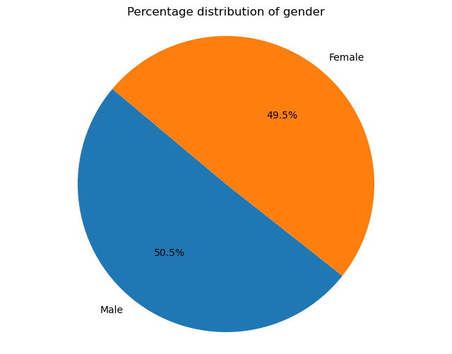

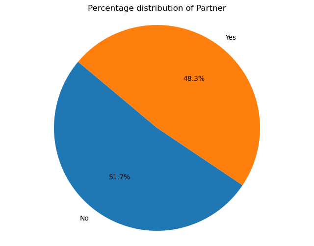

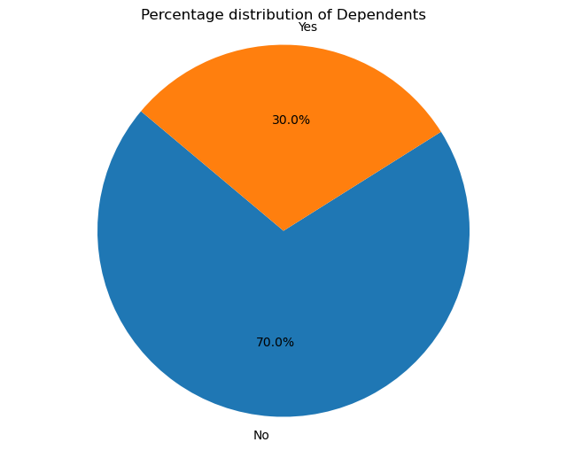

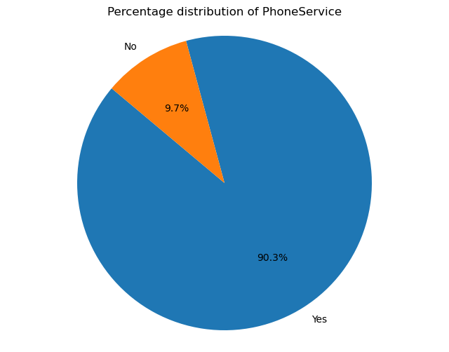

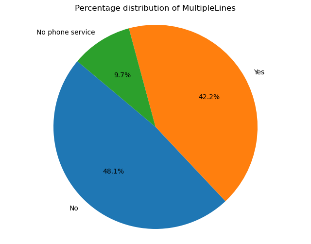

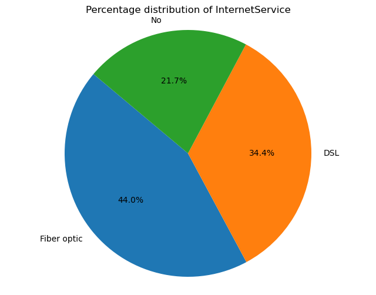

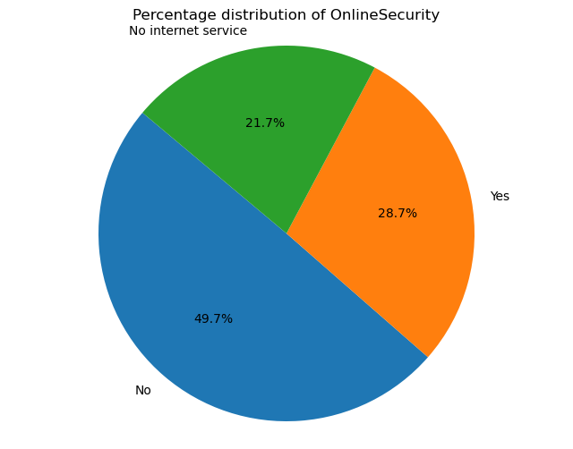

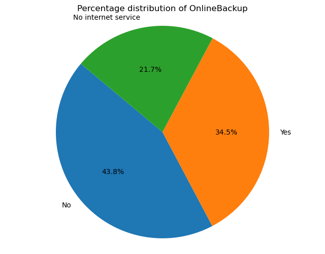

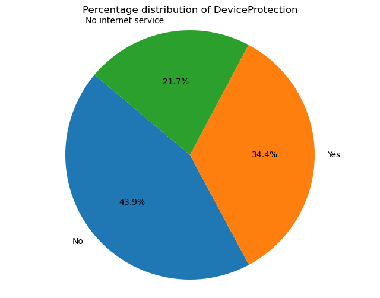

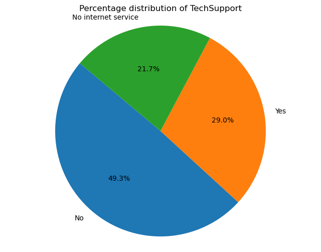

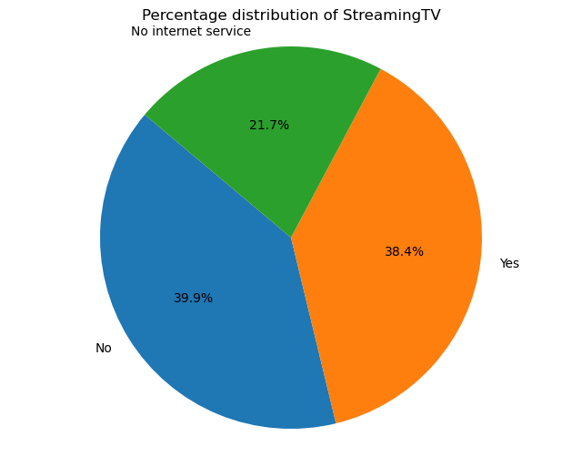

[6 more figures not shown]

```python
import matplotlib.pyplot as plt

def plot_categorical_pie_charts(dataframe):
    # Find categorical columns
    categorical_columns = dataframe.select_dtypes(include=['object', 'category']).columns

    # Plot pie charts for categorical columns
    for column in categorical_columns:
        counts = dataframe[column].value_counts()
        plt.figure(figsize=(8, 6))
        plt.pie(counts, labels=counts.index, autopct='%1.1f%%', startangle=140)
        plt.title(f'Percentage distribution of {column}')
        plt.axis('equal')  # Equal aspect ratio ensures that pie is drawn as a circle
        plt.show()

# Assuming 'merged_telecom_df' is the DataFrame you want to visualize
plot_categorical_pie_charts(merged_telecom_df)
```

### D. Share insights for C. [2 Marks]

The pie charts generated for the categorical features can provide insights into the distribution of different categories within each feature. Here are some insights you might gather from the pie charts:

1. **Gender Distribution:**
   - The pie chart for the 'gender' feature can show the distribution of male and female customers.
   - Insights: Understanding the gender distribution might help tailor marketing or communication strategies to specific demographics.
2. **Internet Service Distribution:**
   - The pie chart for the 'InternetService' feature can display the distribution of customers based on their internet service type (e.g., DSL, Fiber optic, No internet service).
   - Insights: This information is crucial for understanding the popularity of different internet services and may influence service improvement or marketing efforts.
3. **Contract Distribution:**
   - The pie chart for the 'Contract' feature can reveal the distribution of customers based on their contract type (e.g., month-to-month, one year, two years).
   - Insights: Understanding contract preferences can guide the development of customer retention strategies, especially for customers on month-to-month contracts.
4. **Payment Method Distribution:**
   - The pie chart for the 'PaymentMethod' feature can show the distribution of customers using different payment methods.
   - Insights: Knowledge of the preferred payment methods can influence billing and payment process optimizations.
5. **Churn Distribution:**
   - If 'Churn' is a categorical feature (e.g., Yes/No), a pie chart can illustrate the proportion of customers who churned versus those who didn't.
   - Insights: Understanding the churn distribution is crucial for identifying the scale of customer retention challenges and planning appropriate interventions.
6. **Partner and Dependents Distribution:**
   - If 'Partner' and 'Dependents' are categorical features, their respective pie charts can show the distribution of customers with or without partners and dependents.
   - Insights: This information might influence marketing strategies, such as family-oriented promotions or services.

These insights provide a high-level overview of the categorical feature distributions and can guide further analysis and decision-making in the context of customer retention strategies.

### E. Encode all the appropriate Categorical features with the best suitable approach. [2 Marks]

```python
# Assuming 'merged_telecom_df' is the DataFrame containing categorical features to be encoded

# Select categorical columns for encoding
categorical_columns = merged_telecom_df.select_dtypes(include=['object', 'category']).columns

# Perform one-hot encoding using get_dummies
encoded_df = pd.get_dummies(merged_telecom_df, columns=categorical_columns)

# Display the encoded DataFrame
print(encoded_df.head())
```

```
   SeniorCitizen  tenure  MonthlyCharges  customerID_0002-ORFBO  \
0              0       1           29.85                      0
1              0      34           56.95                      0
2              0       2           53.85                      0
3              0      45           42.30                      0
4              0       2           70.70                      0

   customerID_0003-MKNFE  customerID_0004-TLHLJ  customerID_0011-IGKFF  \
0                      0                      0                      0
1                      0                      0                      0
2                      0                      0                      0
3                      0                      0                      0
4                      0                      0                      0

   customerID_0013-EXCHZ  customerID_0013-MHZWF  customerID_0013-SMEOE  ...  \
```

[output cut: 28 more lines]

### F. Split the data into 80% train and 20% test. [1 Marks]

```python
from sklearn.model_selection import train_test_split

# Assuming 'encoded_df' is the DataFrame containing the features and target variable 'MonthlyCharges'
# Make sure 'MonthlyCharges' is present in  DataFrame

# Identify your target variable and features
y = encoded_df['MonthlyCharges']  # Target variable
X = encoded_df.drop('MonthlyCharges', axis=1)  # Features (excluding the target variable 'Churn')

# Split the data into 80% train and 20% test
X_train, X_test, y_train, y_test = train_test_split(X, y, test_size=0.2, random_state=42)

# Display the shapes of the resulting sets
print("Train set shape:", X_train.shape, y_train.shape)
print("Test set shape:", X_test.shape, y_test.shape)
```

```
Train set shape: (5634, 13619) (5634,)
Test set shape: (1409, 13619) (1409,)
```

### G. Normalize/Standardize the data with the best suitable approach. [2 Marks]

```python
from sklearn.preprocessing import MinMaxScaler, StandardScaler

# Assuming 'X_train' and 'X_test' are feature sets

# Normalize the data using Min-Max scaling
scaler_minmax = MinMaxScaler()
X_train_normalized = scaler_minmax.fit_transform(X_train)
X_test_normalized = scaler_minmax.transform(X_test)

# Standardize the data using StandardScaler
scaler_standard = StandardScaler()
X_train_standardized = scaler_standard.fit_transform(X_train)
X_test_standardized = scaler_standard.transform(X_test)
```

## 3.Model building and performance improvement : [40 Marks]

### A. Train a model using Decision tree and check the performance of the model on train and test data ( 4 marks )

```python
from sklearn.tree import DecisionTreeRegressor
from sklearn.metrics import mean_squared_error

# Create a Decision Tree model for regression
decision_tree_model = DecisionTreeRegressor(random_state=42)

# Train the model on the standardized training data
decision_tree_model.fit(X_train_standardized, y_train)

# Predictions on training data
train_predictions = decision_tree_model.predict(X_train_standardized)

# Predictions on test data
test_predictions = decision_tree_model.predict(X_test_standardized)

# Evaluate performance on training data (using Mean Squared Error for regression)
train_mse = mean_squared_error(y_train, train_predictions)
print("Train Mean Squared Error:", train_mse)

# Evaluate performance on test data (using Mean Squared Error for regression)
test_mse = mean_squared_error(y_test, test_predictions)
print("Test Mean Squared Error:", test_mse)
```

```
Train Mean Squared Error: 6.048773714154723e-32
Test Mean Squared Error: 2.081517033356991
```

### B. Use grid search and improve the performance of the Decision tree model , check the performance of the model on train and test data , provide the differences observed in performance in Q3.a and Q3.b ( 5 marks )

```python
from sklearn.tree import DecisionTreeClassifier
from sklearn.model_selection import GridSearchCV
from sklearn.metrics import accuracy_score, classification_report

# Create a Decision Tree model
decision_tree_model = DecisionTreeClassifier(random_state=42)

# Define hyperparameters and their values to be searched
param_grid = {
    'criterion': ['gini', 'entropy'],
    'max_depth': [None, 5, 10, 15],
    'min_samples_split': [2, 5, 10],
    'min_samples_leaf': [1, 2, 4]
}

# Perform grid search using cross-validation (5-fold cross-validation in this example)
grid_search = GridSearchCV(estimator=decision_tree_model, param_grid=param_grid, cv=5)
grid_search.fit(X_train_standardized, y_train)

# Get the best parameters found by grid search
best_params = grid_search.best_params_
print("Best Parameters:", best_params)

# Use the best model from grid search for predictions
best_model_dt = grid_search.best_estimator_

# Predictions on training data
train_predictions_dt_gs = best_model_dt.predict(X_train_standardized)

# Predictions on test data
test_predictions_dt_gs = best_model_dt.predict(X_test_standardized)

# Evaluate performance on training data
train_accuracy_dt_gs = accuracy_score(y_train, train_predictions_dt_gs)
print("Decision Tree Train Accuracy after GridSearchCV:", train_accuracy_dt_gs)

# Evaluate performance on test data
test_accuracy_dt_gs = accuracy_score(y_test, test_predictions_dt_gs)
print("Decision Tree Test Accuracy after GridSearchCV:", test_accuracy_dt_gs)

# Display classification report for test data
print("\nClassification Report for Decision Tree after GridSearchCV:")
print(classification_report(y_test, test_predictions_dt_gs))
```

[output not shown]

[output cut: 30 more lines]

[output not shown]

### C. Train a model using Random forest and check the performance of the model on train and test data ( 4 marks )

```python
from sklearn.ensemble import RandomForestClassifier
from sklearn.metrics import accuracy_score, classification_report

# Print unique values in y_train for debugging
print("Unique values in y_train:", y_train.unique())

# Create a Random Forest model
random_forest_model = RandomForestClassifier(random_state=42)

# Train the model on the standardized training data
random_forest_model.fit(X_train_standardized, y_train)

# Predictions on training data
train_predictions_rf = random_forest_model.predict(X_train_standardized)

# Predictions on test data
test_predictions_rf = random_forest_model.predict(X_test_standardized)

# Evaluate performance on training data
train_accuracy_rf = accuracy_score(y_train, train_predictions_rf)
print("Random Forest Train Accuracy:", train_accuracy_rf)

# Evaluate performance on test data
test_accuracy_rf = accuracy_score(y_test, test_predictions_rf)
print("Random Forest Test Accuracy:", test_accuracy_rf)

# Display classification report for test data
print("\nClassification Report for Random Forest on Test Data:")
print(classification_report(y_test, test_predictions_rf))
```

[output not shown]

### D. Use grid search and improve the performance of the Random tree model , check the performance of the model on train and test data , provide the differences observed in performance in Q3.c and Q3.d ( 5 marks )

```python
from sklearn.ensemble import RandomForestClassifier
from sklearn.model_selection import GridSearchCV
from sklearn.metrics import accuracy_score, classification_report

# Create a Random Forest model
random_forest_model = RandomForestClassifier(random_state=42)

# Define hyperparameters and their values to be searched
param_grid = {
    'n_estimators': [50, 100, 150],
    'max_depth': [None, 5, 10, 15],
    'min_samples_split': [2, 5, 10],
    'min_samples_leaf': [1, 2, 4]
}

# Perform grid search using cross-validation (5-fold cross-validation in this example)
grid_search = GridSearchCV(estimator=random_forest_model, param_grid=param_grid, cv=5)
grid_search.fit(X_train_standardized, y_train)

# Get the best parameters found by grid search
best_params = grid_search.best_params_
print("Best Parameters:", best_params)

# Use the best model from grid search for predictions
best_model = grid_search.best_estimator_

# Predictions on training data
train_predictions_rf_gs = best_model.predict(X_train_standardized)

# Predictions on test data
test_predictions_rf_gs = best_model.predict(X_test_standardized)

# Evaluate performance on training data
train_accuracy_rf_gs = accuracy_score(y_train, train_predictions_rf_gs)
print("Random Forest Train Accuracy after GridSearchCV:", train_accuracy_rf_gs)

# Evaluate performance on test data
test_accuracy_rf_gs = accuracy_score(y_test, test_predictions_rf_gs)
print("Random Forest Test Accuracy after GridSearchCV:", test_accuracy_rf_gs)

# Display classification report for test data
print("\nClassification Report for Random Forest after GridSearchCV:")
print(classification_report(y_test, test_predictions_rf_gs))
```

[output not shown]

### E. Train a model using Adaboost and check the performance of the model on train and test data ( 4 marks )

```python
from sklearn.ensemble import AdaBoostClassifier
from sklearn.metrics import accuracy_score, classification_report

# Create an AdaBoost model
adaboost_model = AdaBoostClassifier(random_state=42)

# Train the model on the standardized training data
adaboost_model.fit(X_train_standardized, y_train)

# Predictions on training data
train_predictions_adaboost = adaboost_model.predict(X_train_standardized)

# Predictions on test data
test_predictions_adaboost = adaboost_model.predict(X_test_standardized)

# Evaluate performance on training data
train_accuracy_adaboost = accuracy_score(y_train, train_predictions_adaboost)
print("AdaBoost Train Accuracy:", train_accuracy_adaboost)

# Evaluate performance on test data
test_accuracy_adaboost = accuracy_score(y_test, test_predictions_adaboost)
print("AdaBoost Test Accuracy:", test_accuracy_adaboost)

# Display classification report for test data
print("\nClassification Report for AdaBoost on Test Data:")
print(classification_report(y_test, test_predictions_adaboost))
```

[output not shown]

### F. Use grid search and improve the performance of the Adaboost model , check the performance of the model on train and test data , provide the differences observed in performance in Q3.e and Q3.f ( 5 marks )

```python
from sklearn.ensemble import AdaBoostClassifier
from sklearn.model_selection import GridSearchCV
from sklearn.metrics import accuracy_score, classification_report

# Create an AdaBoost model
adaboost_model = AdaBoostClassifier(random_state=42)

# Define hyperparameters and their values to be searched
param_grid = {
    'n_estimators': [50, 100, 150],
    'learning_rate': [0.01, 0.1, 0.5, 1.0]
}

# Perform grid search using cross-validation (5-fold cross-validation in this example)
grid_search = GridSearchCV(estimator=adaboost_model, param_grid=param_grid, cv=5)
grid_search.fit(X_train_standardized, y_train)

# Get the best parameters found by grid search
best_params = grid_search.best_params_
print("Best Parameters:", best_params)

# Use the best model from grid search for predictions
best_model_adaboost = grid_search.best_estimator_

# Predictions on training data
train_predictions_adaboost_gs = best_model_adaboost.predict(X_train_standardized)

# Predictions on test data
test_predictions_adaboost_gs = best_model_adaboost.predict(X_test_standardized)

# Evaluate performance on training data
train_accuracy_adaboost_gs = accuracy_score(y_train, train_predictions_adaboost_gs)
print("AdaBoost Train Accuracy after GridSearchCV:", train_accuracy_adaboost_gs)

# Evaluate performance on test data
test_accuracy_adaboost_gs = accuracy_score(y_test, test_predictions_adaboost_gs)
print("AdaBoost Test Accuracy after GridSearchCV:", test_accuracy_adaboost_gs)

# Display classification report for test data
print("\nClassification Report for AdaBoost after GridSearchCV:")
print(classification_report(y_test, test_predictions_adaboost_gs))
```

[output not shown]

### G. Train a model using GradientBoost and check the performance of the model on train and test data ( 4 marks )

```python
from sklearn.ensemble import GradientBoostingClassifier
from sklearn.metrics import accuracy_score, classification_report

# Create a Gradient Boosting model
gradient_boost_model = GradientBoostingClassifier(random_state=42)

# Train the model on the standardized training data
gradient_boost_model.fit(X_train_standardized, y_train)

# Predictions on training data
train_predictions_gradient_boost = gradient_boost_model.predict(X_train_standardized)

# Predictions on test data
test_predictions_gradient_boost = gradient_boost_model.predict(X_test_standardized)

# Evaluate performance on training data
train_accuracy_gradient_boost = accuracy_score(y_train, train_predictions_gradient_boost)
print("Gradient Boosting Train Accuracy:", train_accuracy_gradient_boost)

# Evaluate performance on test data
test_accuracy_gradient_boost = accuracy_score(y_test, test_predictions_gradient_boost)
print("Gradient Boosting Test Accuracy:", test_accuracy_gradient_boost)

# Display classification report for test data
print("\nClassification Report for Gradient Boosting on Test Data:")
print(classification_report(y_test, test_predictions_gradient_boost))
```

[output not shown]

### H. Use grid search and improve the performance of the GradientBoost model , check the performance of the model on train and test data , provide the differences observed in performance in Q3.g and Q3.h ( 5 marks )

```python
from sklearn.ensemble import GradientBoostingClassifier
from sklearn.model_selection import GridSearchCV
from sklearn.metrics import accuracy_score, classification_report

# Create a Gradient Boosting model
gradient_boost_model = GradientBoostingClassifier(random_state=42)

# Define hyperparameters and their values to be searched
param_grid = {
    'n_estimators': [50, 100, 150],
    'learning_rate': [0.01, 0.1, 0.5],
    'max_depth': [3, 5, 7],
    'min_samples_split': [2, 5, 10],
    'min_samples_leaf': [1, 2, 4]
}

# Perform grid search using cross-validation (5-fold cross-validation in this example)
grid_search = GridSearchCV(estimator=gradient_boost_model, param_grid=param_grid, cv=5)
grid_search.fit(X_train_standardized, y_train)

# Get the best parameters found by grid search
best_params = grid_search.best_params_
print("Best Parameters:", best_params)

# Use the best model from grid search for predictions
best_model_gradient_boost = grid_search.best_estimator_

# Predictions on training data
train_predictions_gradient_boost_gs = best_model_gradient_boost.predict(X_train_standardized)

# Predictions on test data
test_predictions_gradient_boost_gs = best_model_gradient_boost.predict(X_test_standardized)

# Evaluate performance on training data
train_accuracy_gradient_boost_gs = accuracy_score(y_train, train_predictions_gradient_boost_gs)
print("Gradient Boosting Train Accuracy after GridSearchCV:", train_accuracy_gradient_boost_gs)

# Evaluate performance on test data
test_accuracy_gradient_boost_gs = accuracy_score(y_test, test_predictions_gradient_boost_gs)
print("Gradient Boosting Test Accuracy after GridSearchCV:", test_accuracy_gradient_boost_gs)

# Display classification report for test data
print("\nClassification Report for Gradient Boosting after GridSearchCV:")
print(classification_report(y_test, test_predictions_gradient_boost_gs))
```

[output not shown]

### I. Provide detailed analysis of the below steps (4 marks ) :

(1) Compare the performance of each model in train stage and test stage

(2) Provide your observation on which model performed the best

(3) Provide your reasoning on why the model performed best

(4) Provide your final conclusion on your observation

## Gradient Boosting Strengths:

Ensemble Method: Gradient Boosting is an ensemble method that combines the predictions of multiple weak learners, improving overall performance.

Sequential Learning: It builds trees sequentially, focusing on correcting errors of the previous ones, which can capture complex relationships in the data.

(4) Provide your final conclusion on your observation

## Gradient Boosting Model Recommendation:

Considerations:

It's important to monitor the model's performance over time and update it if necessary.

Collaborate with domain experts to understand the practical implications of the model's predictions and adjust strategies accordingly.